# A2_predicting_taxi_tips

ray_wang

2020.05

## Using the data from week 2 of January 2016 (week2.csv), construct a model that predicts the amount of a tip. Evaluate the mean squared error of this model on the data from week 4 of January 2016 (week4.csv).

```r
options(warn = -1)
library(dplyr)
library(tidyverse)
library(lubridate)
library(leaflet)
library(leaps)
library(s20x)
```

# data clean

Read the csv data into R.

```r
week2 = read.csv(file= "week2.csv", header = TRUE)
week4 = read.csv(file= "week4.csv", header = TRUE)
nrow(week2)
```

```
## [1] 2651287
```

```r
tail(week2)
```

|  | VendorID | tpep_pickup_datetime | tpep_dropoff_datetime | passenger_count | trip_distance | pickup_longitude | pickup_latitude | RatecodeID | store_and_fwd_flag | dropoff_longitude | dropoff_latitude | payment_type | fare_amount | extra | mta_tax | tip_amount | tolls_amount | improvement_surcharge | total_amount |
| --- | --- | --- | --- | --- | --- | --- | --- | --- | --- | --- | --- | --- | --- | --- | --- | --- | --- | --- | --- |
| 2651282 | 2 | 2016-01-10T23:08:50Z | 2016-01-10T23:20:33Z | 1 | 3.37 | -73.98880 | 40.77433 | 1 | N | -73.99277 | 40.73814 | 2 | 12.5 | 0.5 | 0.5 | 0 | 0 | 0.3 | 13.8 |
| 2651283 | 2 | 2016-01-10T23:08:50Z | 2016-01-10T23:19:43Z | 3 | 3.73 | -73.99147 | 40.72707 | 1 | N | -73.95695 | 40.77166 | 1 | 12.5 | 0.5 | 0.5 | 1 | 0 | 0.3 | 14.8 |
| 2651284 | 2 | 2016-01-10T23:08:50Z | 2016-01-10T23:47:47Z | 6 | 12.70 | -73.87111 | 40.77377 | 1 | N | -73.94677 | 40.64292 | 1 | 41.5 | 0.5 | 0.5 | 0 | 0 | 0.3 | 42.8 |
| 2651285 | 2 | 2016-01-10T23:08:52Z | 2016-01-10T23:27:08Z | 5 | 5.16 | -73.97222 | 40.75660 | 1 | N | -73.96131 | 40.81111 | 2 | 18.0 | 0.5 | 0.5 | 0 | 0 | 0.3 | 19.3 |
| 2651286 | 2 | 2016-01-10T23:08:52Z | 2016-01-10T23:13:13Z | 3 | 0.75 | -73.99587 | 40.72525 | 1 | N | -74.00457 | 40.72131 | 2 | 5.5 | 0.5 | 0.5 | 0 | 0 | 0.3 | 6.8 |
| 2651287 | 2 | 2016-01-10T23:08:53Z | 2016-01-10T23:13:13Z | 1 | 1.06 | -73.98111 | 40.76831 | 1 | N | -73.96598 | 40.76628 | 2 | 5.5 | 0.5 | 0.5 | 0 | 0 | 0.3 | 6.8 |

```r
summary(week2)
```

```
##     VendorID     tpep_pickup_datetime tpep_dropoff_datetime passenger_count
##  Min.   :1.000   Length:2651287       Length:2651287        Min.   :0.000
##  1st Qu.:1.000   Class :character     Class :character      1st Qu.:1.000
##  Median :2.000   Mode  :character     Mode  :character      Median :1.000
##  Mean   :1.532                                              Mean   :1.659
##  3rd Qu.:2.000                                              3rd Qu.:2.000
##  Max.   :2.000                                              Max.   :9.000
##  trip_distance     pickup_longitude  pickup_latitude   RatecodeID
##  Min.   :  0.000   Min.   :-121.93   Min.   : 0.00   Min.   : 1.000
##  1st Qu.:  1.000   1st Qu.: -73.99   1st Qu.:40.74   1st Qu.: 1.000
##  Median :  1.630   Median : -73.98   Median :40.75   Median : 1.000
##  Mean   :  2.809   Mean   : -72.84   Mean   :40.13   Mean   : 1.036
##  3rd Qu.:  3.000   3rd Qu.: -73.97   3rd Qu.:40.77   3rd Qu.: 1.000
##  Max.   :502.200   Max.   :   0.00   Max.   :46.31   Max.   :99.000
##  store_and_fwd_flag dropoff_longitude dropoff_latitude  payment_type
##  Length:2651287     Min.   :-121.93   Min.   : 0.00    Min.   :1.000
##  Class :character   1st Qu.: -73.99   1st Qu.:40.74    1st Qu.:1.000
##  Mode  :character   Median : -73.98   Median :40.75    Median :1.000
##                     Mean   : -72.91   Mean   :40.17    Mean   :1.337
##                     3rd Qu.: -73.96   3rd Qu.:40.77    3rd Qu.:2.000
##                     Max.   :   0.00   Max.   :52.75    Max.   :4.000
##   fare_amount          extra             mta_tax          tip_amount
##  Min.   :-957.60   Min.   :-35.6400   Min.   :-0.5000   Min.   :-220.800
##  1st Qu.:   6.50   1st Qu.:  0.0000   1st Qu.: 0.5000   1st Qu.:   0.000
##  Median :   9.00   Median :  0.0000   Median : 0.5000   Median :   1.320
##  Mean   :  12.06   Mean   :  0.3235   Mean   : 0.4978   Mean   :   1.728
##  3rd Qu.:  13.50   3rd Qu.:  0.5000   3rd Qu.: 0.5000   3rd Qu.:   2.260
##  Max.   :3039.00   Max.   :  4.1000   Max.   :36.4400   Max.   : 900.000
##   tolls_amount      improvement_surcharge  total_amount
##  Min.   :-12.5000   Min.   :-0.3000       Min.   :-958.40
##  1st Qu.:  0.0000   1st Qu.: 0.3000       1st Qu.:   8.30
##  Median :  0.0000   Median : 0.3000       Median :  11.30
##  Mean   :  0.2746   Mean   : 0.2998       Mean   :  15.18
##  3rd Qu.:  0.0000   3rd Qu.: 0.3000       3rd Qu.:  16.56
##  Max.   :811.0000   Max.   : 0.3000       Max.   :3045.34
```

After reading the description of this taxi data,I find there are some columns that are clearly uninformative.

```r
week2[which(week2$payment_type != 1& week2$tip_amount != 0 ),"tip_amount"]
```

```
##  [1]   1.06   2.32 444.48  13.76   4.59   1.45   2.00   2.79   3.96   1.50
## [11]  19.59   1.66   2.16   2.16   8.00   4.00   1.00   1.96  -2.85   1.16
## [21]  -2.40  -0.99 -10.56  18.00 -10.56   6.36  -0.86  -2.70  -2.70   1.86
## [31]   8.76  -0.66  -0.66  -0.66  -2.70   8.89  -0.64  -0.86   1.00  -2.70
## [41]  -2.70  -1.29  -1.20   7.66  -1.08  -1.16  -1.00  -1.58
```

There are some illegal negative value. Let’s do the data clean.

```r
isAirport <- function(x,y){
  longt <- x;
  lat <- y;
  airport_longt = -73.7785;
  airport_lat =  40.6415;
  return( abs(x-airport_longt)<=0.025&abs(y-airport_lat)<=0.020)
}

isWeekend <- function(dow){
  return( dow == "Sat" | dow == "Sun")
}
taxi <- subset(week2, select = -c(extra, mta_tax, improvement_surcharge))%>%
  filter(payment_type == '1', tip_amount >= 0, fare_amount >= 0 ,tip_amount < 1000,
         trip_distance >= 0,trip_distance< 1000,tolls_amount>= 0, RatecodeID <= 6)%>%
  separate(col= tpep_dropoff_datetime, into=c("dropoff_day", "dropoff_time"), sep = c('T') )%>%
  separate(col= dropoff_time, into=c("dropoff_time", "rest"), sep = 'Z' )%>%
  unite("dropoff_datetime", dropoff_day, dropoff_time,sep = ' ')%>%
  separate(col= tpep_pickup_datetime, into=c("pickup_day", "pickup_time"), sep = c('T') )%>%
  separate(col= pickup_time, into=c("pickup_time", "rest2"), sep = 'Z' )%>%
  unite("pickup_datetime", pickup_day, pickup_time,sep = ' ')%>%
  select(-c(rest, rest2,payment_type))%>%
  mutate(
    dow = wday(pickup_datetime,label=TRUE,abbr=TRUE, week_start = 1, locale = Sys.setlocale("LC_TIME", "American")),
    hour_trip_start = hour(pickup_datetime),
    trip_duration = as.numeric(difftime(dropoff_datetime,pickup_datetime,units="mins")),
    gotoAirport = isAirport(dropoff_longitude,dropoff_latitude),
    leaveAirport =isAirport(pickup_longitude,pickup_latitude),
    isWeekend = isWeekend(dow)
  )

taxi$WhatTime <- with(taxi,  ifelse(hour_trip_start >= 5 & hour_trip_start<=11, "early morning",
                                     ifelse(hour_trip_start>11 & hour_trip_start<=16, "afternoon",
                                            ifelse(hour_trip_start>16 & hour_trip_start<= 19, "evening","night"))))
```

## Draw plots

We can draw the barplot fair quickly, but we can’t draw the plot which including many points, like qpplot().

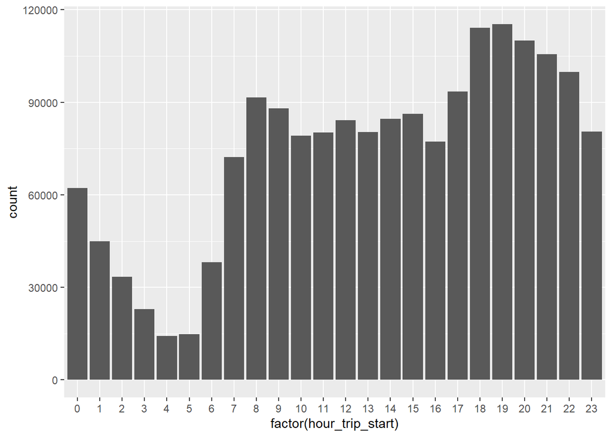

```r
taxi %>%
  ggplot(aes(x=factor(hour_trip_start))) + geom_bar()
```

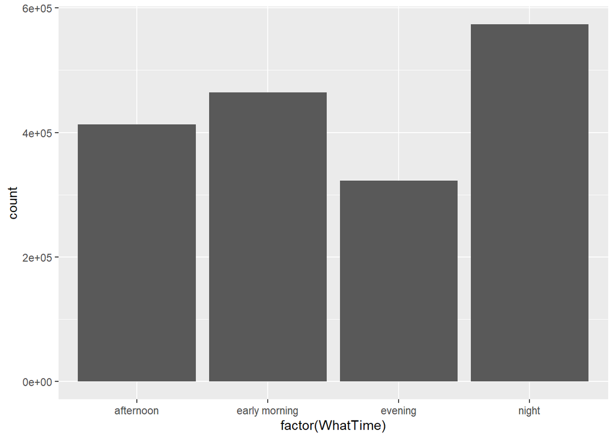

```r
taxi %>%
  ggplot(aes(x=factor(WhatTime))) + geom_bar()
```

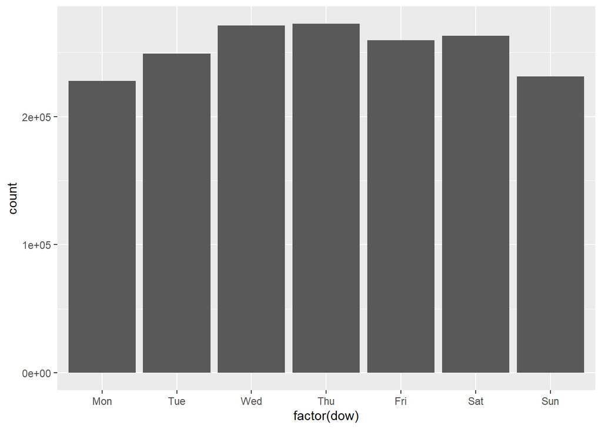

```r
taxi %>%
  ggplot(aes(x=factor(dow))) + geom_bar()
```

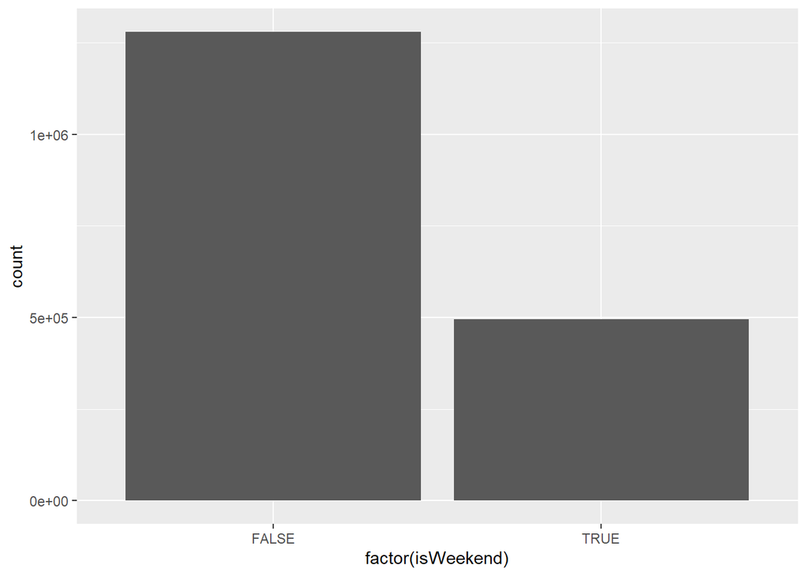

```r
taxi%>%
  ggplot(aes(x=factor(isWeekend))) + geom_bar()
```

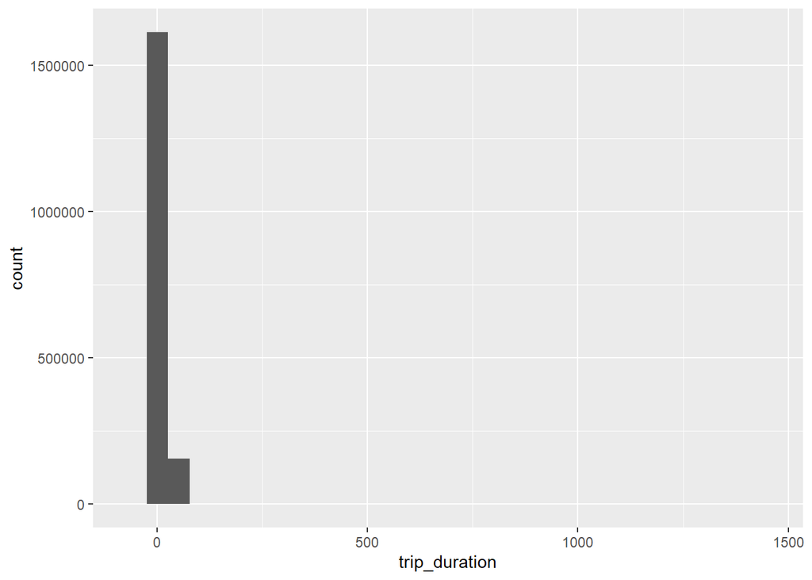

```r
taxi %>% ggplot(aes(trip_duration)) + geom_histogram()
```

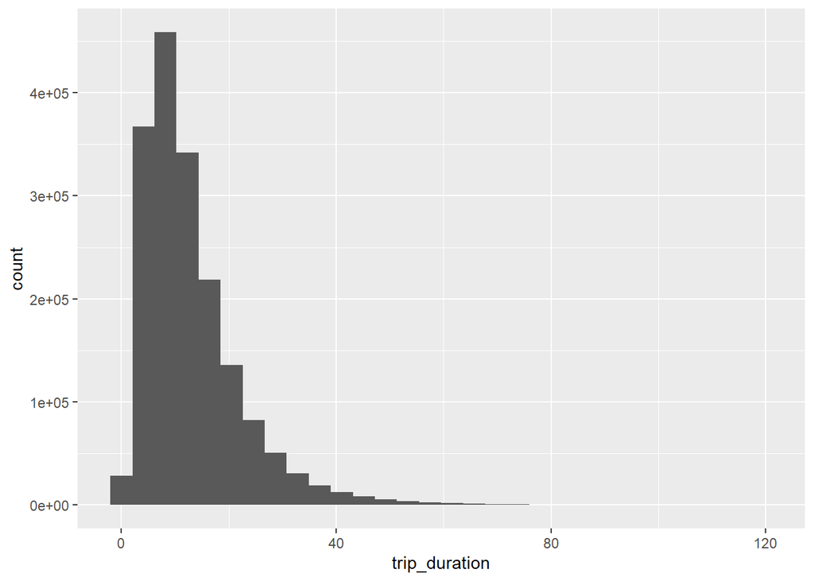

```r
taxi %>% filter(trip_duration < 120 & trip_duration >0) %>% ggplot(aes(trip_duration)) + geom_histogram()
```

I want to see what these trips looks like in the map and draw some point plots. But the data is too big for my PC, so I have to take a random subsample from the origin data.

```r
sm_taxi <- taxi %>% sample_n(1e4)
min_lat <- 40.577
max_lat <- 40.918
min_long <- -74.15
max_long <- -73.700
sm_taxi <- sm_taxi %>% filter(pickup_longitude > min_long, pickup_longitude < max_long, pickup_latitude > min_lat, pickup_latitude < max_lat)
airport_taxi <-sm_taxi%>%filter(leaveAirport == TRUE)
#draw map in R
leaflet(sm_taxi) %>%
  addTiles() %>%
  addCircleMarkers(~pickup_longitude,~pickup_latitude, radius=2,stroke = FALSE, opacity=1, fillOpacity =1)
```

[interactive chart not shown]

```r
leaflet(airport_taxi) %>%
  addTiles() %>%
  addCircleMarkers(~pickup_longitude,~pickup_latitude, radius=2,stroke = FALSE, opacity=1, fillOpacity =1)
```

[interactive chart not shown]

From the map, we find there are some airport trips. We can infer that the airport trip could be a factor in our model. So we mutate two new columns: leaveAirport and gotoAirport.

Draw some plots to to find potential relationships between variables to include eg time of day/week/distance etc.

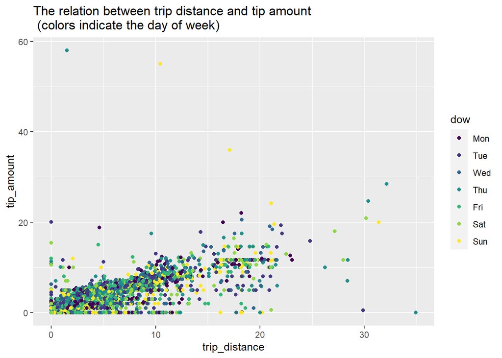

```r
sm_taxi <- taxi %>% sample_n(1e4)

qplot(trip_distance, tip_amount, col=dow, data = sm_taxi,
               main="The relation between trip distance and tip amount \n (colors indicate the day of week)")
```

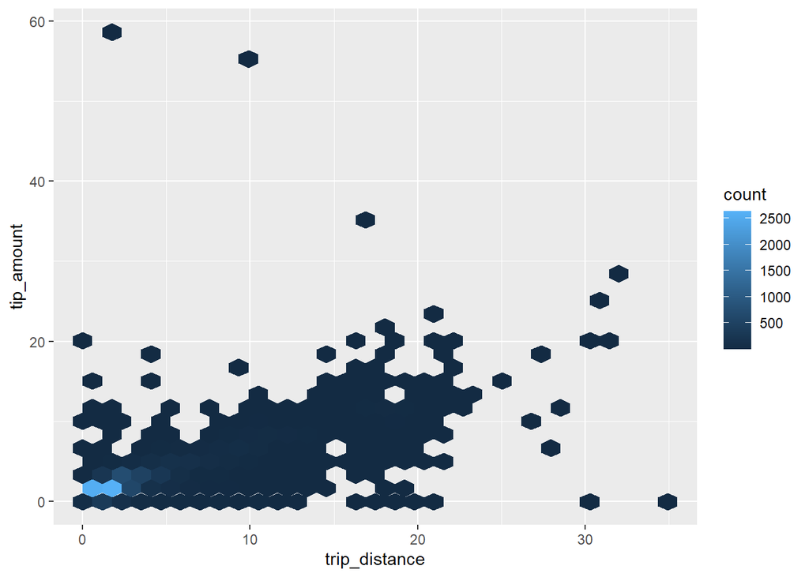

```r
ggplot(sm_taxi, aes(trip_distance, tip_amount)) + geom_hex()
```

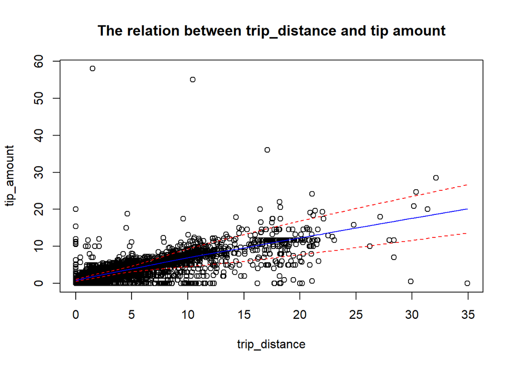

```r
trendscatter(tip_amount~ trip_distance,main = "The relation between trip_distance and tip amount" ,data = sm_taxi)
```

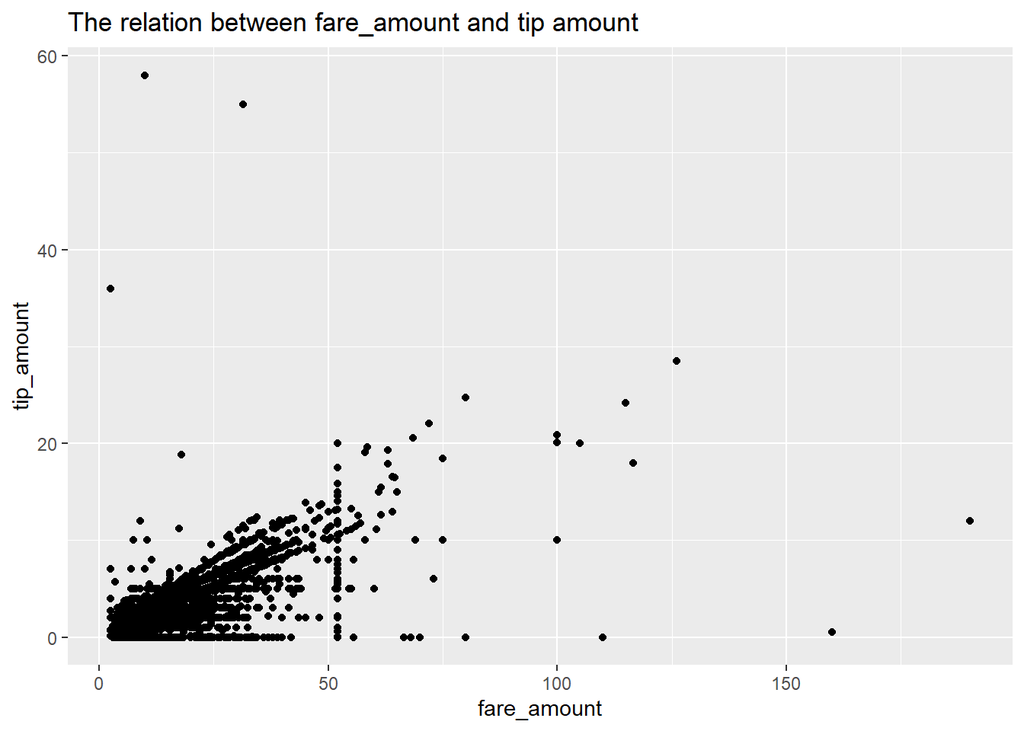

```r
qplot(fare_amount, tip_amount, data = sm_taxi,
      main="The relation between fare_amount and tip amount")
```

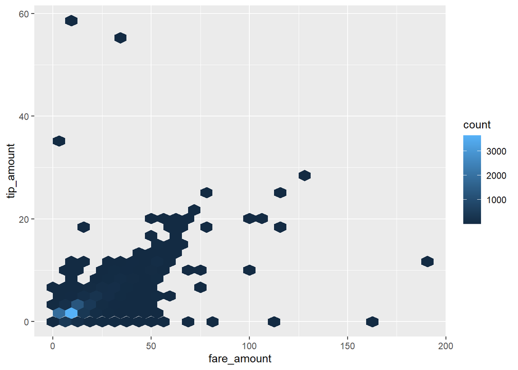

```r
ggplot(sm_taxi, aes(fare_amount, tip_amount)) + geom_hex()
```

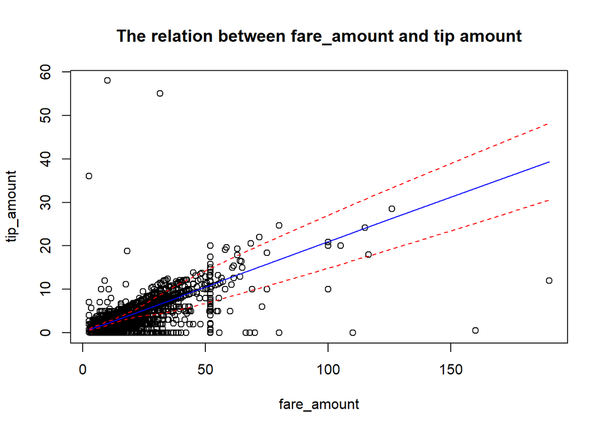

```r
trendscatter(tip_amount~ fare_amount,main = "The relation between fare_amount and tip amount" ,data = sm_taxi)
```

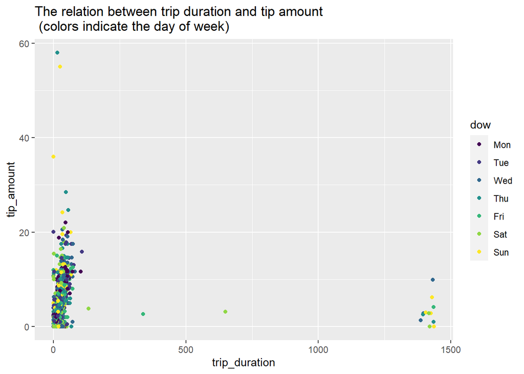

```r
qplot(trip_duration, tip_amount, col=dow, data = sm_taxi,
      main="The relation between trip duration and tip amount \n (colors indicate the day of week)")
```

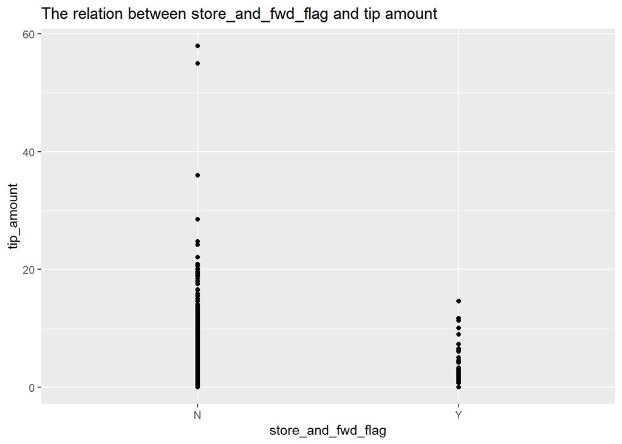

```r
qplot(store_and_fwd_flag, tip_amount, data = sm_taxi,
      main="The relation between store_and_fwd_flag and tip amount ")
```

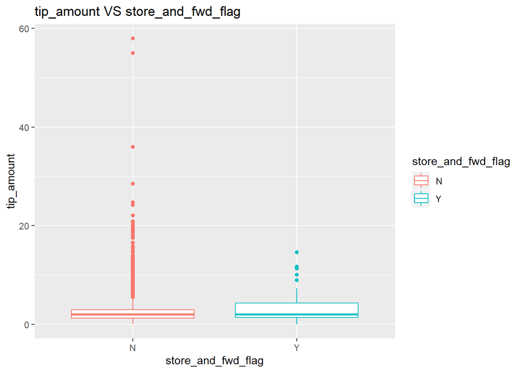

```r
qplot(store_and_fwd_flag, tip_amount,data = sm_taxi, geom= "boxplot" , col = store_and_fwd_flag)+ ggtitle("tip_amount VS store_and_fwd_flag ")
```

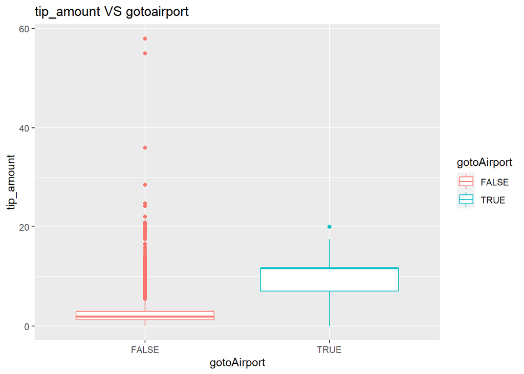

```r
qplot(gotoAirport, tip_amount,data = sm_taxi, geom= "boxplot", col = gotoAirport)+
ggtitle("tip_amount VS gotoairport")
```

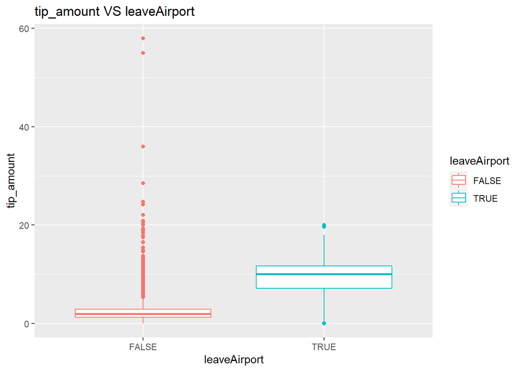

```r
qplot(leaveAirport, tip_amount,data = sm_taxi, geom= "boxplot", col = leaveAirport)+
ggtitle("tip_amount VS leaveAirport")
```

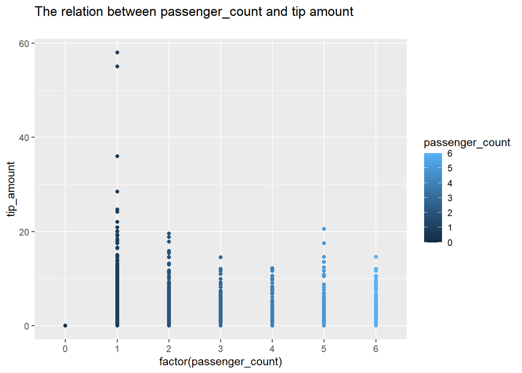

```r
qplot(factor(passenger_count), tip_amount, data = sm_taxi, col = passenger_count,
      main="The relation between passenger_count and tip amount \n ")
```

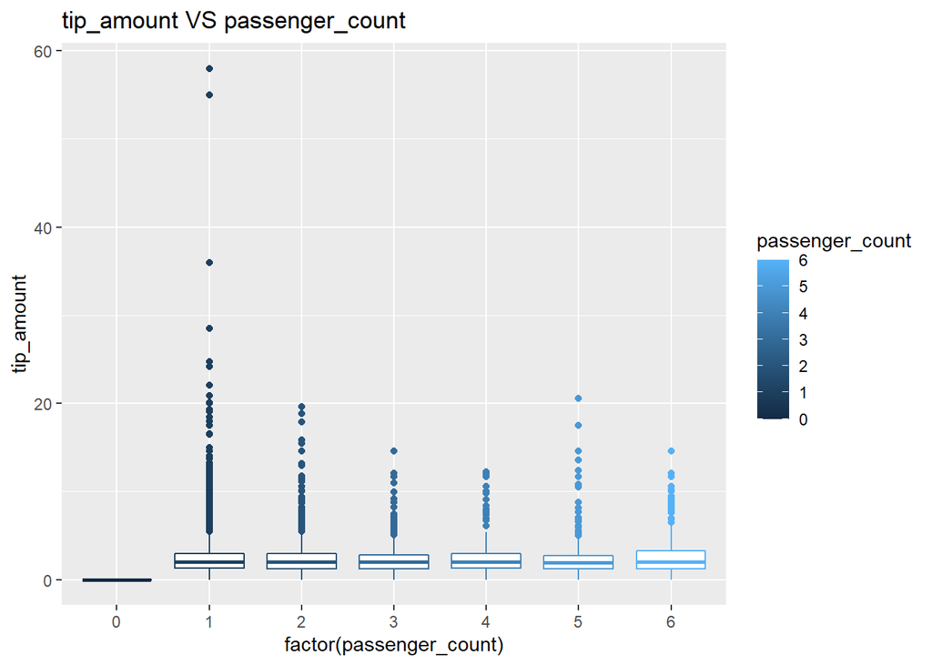

```r
qplot(factor(passenger_count), tip_amount,data = sm_taxi, col = passenger_count, geom= "boxplot")+
ggtitle("tip_amount VS passenger_count")
```

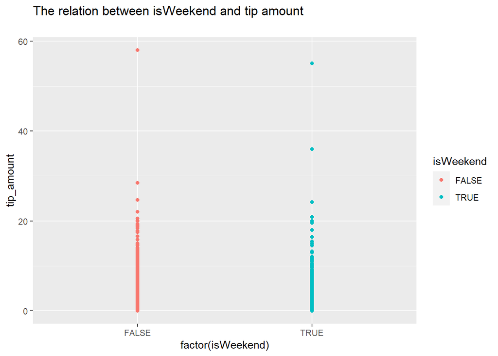

```r
qplot(factor(isWeekend), tip_amount, data = sm_taxi, col = isWeekend,
      main="The relation between isWeekend and tip amount \n ")
```

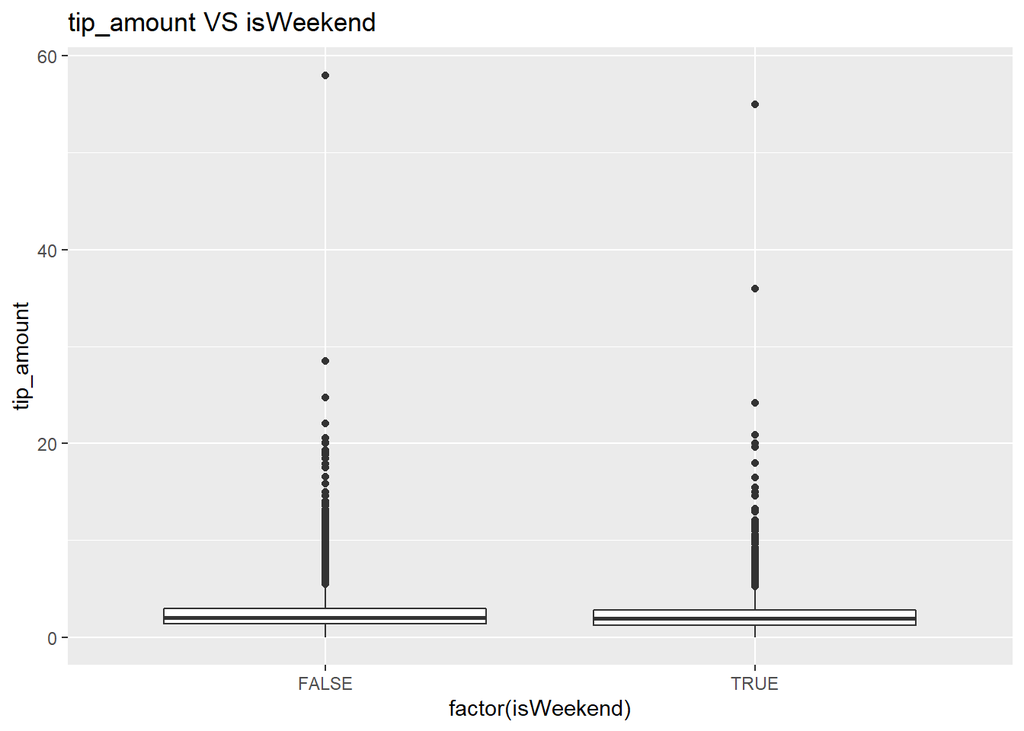

```r
qplot(factor(isWeekend), tip_amount,data = sm_taxi, geom= "boxplot")+
ggtitle("tip_amount VS isWeekend")
```

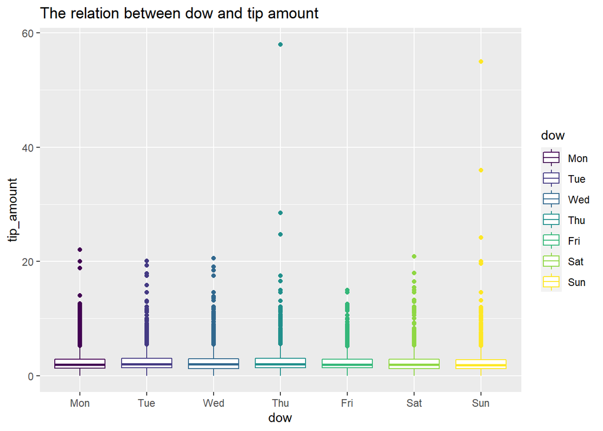

```r
qplot(dow, tip_amount, data = sm_taxi,geom= "boxplot", col = dow,
      main="The relation between dow and tip amount ")
```

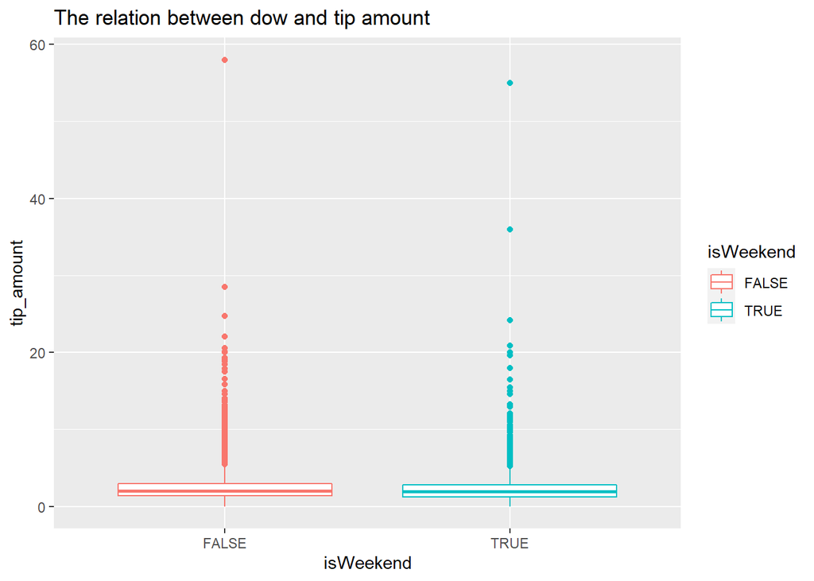

```r
qplot(isWeekend, tip_amount, data = sm_taxi,geom= "boxplot", col = isWeekend,
      main="The relation between dow and tip amount ")
```

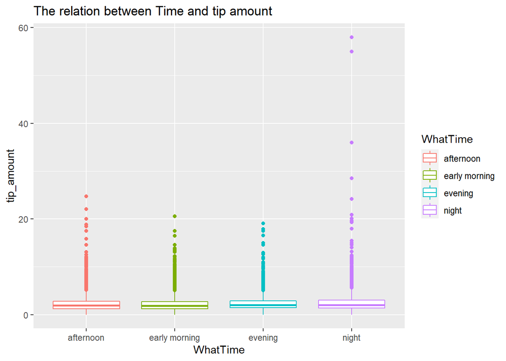

```r
qplot(WhatTime, tip_amount, data = sm_taxi, geom= "boxplot", col = WhatTime,
      main="The relation between Time and tip amount  ")
```

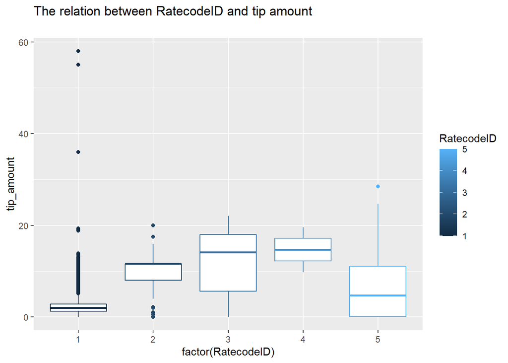

```r
qplot(factor(RatecodeID), tip_amount, col= RatecodeID, data = sm_taxi, geom= "boxplot",
               main="The relation between RatecodeID and tip amount \n ")
```

We find *trip_distance*, *fare_amount*, *RatecodeID* and *airport trips* have big effect on *tip_amount*. The day of week, is weekend or not and what time in a day has slight effect on *tip_amount*.

## Model fit

Before fit the model, we need clean the train data again and prepare the test data week4. The test data also need to be clean because we must have the same columns as the train data wk2 to ensure the prediction works.

```r
taxi_lm <- taxi %>%filter(trip_duration >=0)%>%
  select(-c(hour_trip_start, total_amount, dropoff_datetime, dropoff_longitude,
                          dropoff_latitude, pickup_datetime, pickup_latitude, pickup_longitude, VendorID))%>%
  mutate(
    dow = factor(dow),
    RatecodeID = factor(RatecodeID),
    store_and_fwd_flag = factor(store_and_fwd_flag),
    gotoAirport = factor(gotoAirport),
    leaveAirport = factor(leaveAirport),
    WhatTime = factor( WhatTime),
    isWeekend = factor(isWeekend)
  )
summary(taxi_lm)
```

```
##  passenger_count trip_distance     RatecodeID  store_and_fwd_flag
##  Min.   :0.000   Min.   :  0.000   1:1728712   N:1764335
##  1st Qu.:1.000   1st Qu.:  1.050   2:  35763   Y:   9043
##  Median :1.000   Median :  1.740   3:   2512
##  Mean   :1.647   Mean   :  2.961   4:    622
##  3rd Qu.:2.000   3rd Qu.:  3.170   5:   5768
##  Max.   :9.000   Max.   :191.900   6:      1
##
##   fare_amount       tip_amount       tolls_amount      dow
##  Min.   :  0.00   Min.   :  0.000   Min.   :  0.000   Mon:227682
##  1st Qu.:  6.50   1st Qu.:  1.290   1st Qu.:  0.000   Tue:249041
##  Median :  9.50   Median :  2.000   Median :  0.000   Wed:270815
##  Mean   : 12.55   Mean   :  2.584   Mean   :  0.318   Thu:272277
##  3rd Qu.: 14.00   3rd Qu.:  2.950   3rd Qu.:  0.000   Fri:259272
##  Max.   :998.00   Max.   :900.000   Max.   :100.000   Sat:262931
##                                                       Sun:231360
##  trip_duration      gotoAirport     leaveAirport    isWeekend
##  Min.   :   0.000   FALSE:1761115   FALSE:1739989   FALSE:1279087
##  1st Qu.:   6.567   TRUE :  12263   TRUE :  33389   TRUE : 494291
##  Median :  10.583
##  Mean   :  14.554
##  3rd Qu.:  16.650
##  Max.   :1439.883
##
##           WhatTime
##  afternoon    :412633
##  early morning:464227
##  evening      :322877
##  night        :573641
##
##
##
```

```r
taxi_test <- subset(week4, select = -c(extra, mta_tax, improvement_surcharge))%>%
  filter(payment_type == '1')%>%
  separate(col= tpep_dropoff_datetime, into=c("dropoff_day", "dropoff_time"), sep = c('T') )%>%
  separate(col= dropoff_time, into=c("dropoff_time", "rest"), sep = 'Z' )%>%
  unite("dropoff_datetime", dropoff_day, dropoff_time,sep = ' ')%>%
  separate(col= tpep_pickup_datetime, into=c("pickup_day", "pickup_time"), sep = c('T') )%>%
  separate(col= pickup_time, into=c("pickup_time", "rest2"), sep = 'Z' )%>%
  unite("pickup_datetime", pickup_day, pickup_time,sep = ' ')%>%
  select(-c(rest, rest2,payment_type))%>%
  mutate(
    dow = wday(pickup_datetime,label=TRUE,abbr=TRUE, week_start = 1, locale = Sys.setlocale("LC_TIME", "American")),
    hour_trip_start = hour(pickup_datetime),
    trip_duration = as.numeric(difftime(dropoff_datetime,pickup_datetime,units="mins")),
    gotoAirport = isAirport(dropoff_longitude,dropoff_latitude),
    leaveAirport =isAirport(pickup_longitude,pickup_latitude),
    isWeekend = isWeekend(dow)
  )
taxi_test$WhatTime <- with(taxi_test,  ifelse(hour_trip_start >= 5 & hour_trip_start<=11, "early morning",
                                              ifelse(hour_trip_start>11 & hour_trip_start<=16, "afternoon",
                                                                                                          ifelse(hour_trip_start>16 & hour_trip_start<= 19, "evening","night"))))

taxi_test <- taxi_test%>%select(-c(hour_trip_start, total_amount, dropoff_datetime, dropoff_longitude,
 dropoff_latitude, pickup_datetime, pickup_latitude, pickup_longitude, VendorID))%>%
  filter(tip_amount >= 0, tip_amount <1000,trip_distance >= 0,trip_distance< 1000,fare_amount >= 0 ,tolls_amount>= 0, trip_duration >=0,RatecodeID <= 6)%>%
  mutate(
    dow = factor(dow),
    RatecodeID = factor(RatecodeID),
    store_and_fwd_flag = factor(store_and_fwd_flag),
    gotoAirport = factor(gotoAirport),
    leaveAirport = factor(leaveAirport),
    WhatTime = factor( WhatTime),
    isWeekend = factor(isWeekend)
  )

summary(taxi_test)
```

```
##  passenger_count trip_distance     RatecodeID  store_and_fwd_flag
##  Min.   :0.000   Min.   :  0.000   1:1327882   N:1360208
##  1st Qu.:1.000   1st Qu.:  1.030   2:  30913   Y:   6883
##  Median :1.000   Median :  1.740   3:   2298
##  Mean   :1.639   Mean   :  3.075   4:    661
##  3rd Qu.:2.000   3rd Qu.:  3.260   5:   5335
##  Max.   :9.000   Max.   :192.800   6:      2
##
##   fare_amount       tip_amount      tolls_amount       dow
##  Min.   :  0.00   Min.   :  0.00   Min.   :  0.0000   Mon:189194
##  1st Qu.:  7.00   1st Qu.:  1.36   1st Qu.:  0.0000   Tue:225916
##  Median : 10.00   Median :  2.00   Median :  0.0000   Wed:248898
##  Mean   : 13.84   Mean   :  2.83   Mean   :  0.3582   Thu:266034
##  3rd Qu.: 16.00   3rd Qu.:  3.16   3rd Qu.:  0.0000   Fri:283808
##  Max.   :550.00   Max.   :496.00   Max.   :172.0400   Sat: 49664
##                                                       Sun:103577
##  trip_duration     gotoAirport     leaveAirport    isWeekend
##  Min.   :   0.00   FALSE:1356013   FALSE:1337714   FALSE:1213850
##  1st Qu.:   7.65   TRUE :  11078   TRUE :  29377   TRUE : 153241
##  Median :  12.55
##  Mean   :  17.51
##  3rd Qu.:  20.20
##  Max.   :1439.97
##
##           WhatTime
##  afternoon    :303197
##  early morning:365229
##  evening      :255367
##  night        :443298
##
##
##
```

### Calculate the MSPE and do model selection

Then, fit the model. Here I use backwards selection methods to do the model selection. And use p-value, R-squared, and AIC (Akaike Information Criterion) as the criteria.  
First we should fit a full model. And we should delete *dow* from our model according to plots above.

```r
library(car)
taxi.full = lm(tip_amount ~ .-dow, data =taxi_lm)
summary(taxi.full)
```

```
##
## Call:
## lm(formula = tip_amount ~ . - dow, data = taxi_lm)
##
## Residuals:
##    Min     1Q Median     3Q    Max
## -78.98  -0.27   0.08   0.38 892.32
##
## Coefficients:
##                         Estimate Std. Error t value Pr(>|t|)
## (Intercept)            5.752e-01  4.058e-03 141.733  < 2e-16 ***
## passenger_count        8.469e-05  1.033e-03   0.082   0.9346
## trip_distance          1.166e-01  1.138e-03 102.470  < 2e-16 ***
## RatecodeID2            3.195e-01  1.674e-02  19.084  < 2e-16 ***
## RatecodeID3           -1.620e-01  3.990e-02  -4.060 4.91e-05 ***
## RatecodeID4            8.599e-01  7.351e-02  11.698  < 2e-16 ***
## RatecodeID5           -1.016e+00  2.867e-02 -35.449  < 2e-16 ***
## RatecodeID6            9.508e+00  1.815e+00   5.240 1.61e-07 ***
## store_and_fwd_flagY    4.285e-02  1.910e-02   2.243   0.0249 *
## fare_amount            1.323e-01  3.559e-04 371.653  < 2e-16 ***
## tolls_amount           2.104e-01  1.370e-03 153.546  < 2e-16 ***
## trip_duration         -4.316e-04  2.888e-05 -14.945  < 2e-16 ***
## gotoAirportTRUE       -2.259e-01  2.196e-02 -10.287  < 2e-16 ***
## leaveAirportTRUE      -4.926e-01  1.527e-02 -32.266  < 2e-16 ***
## isWeekendTRUE         -1.184e-01  3.072e-03 -38.553  < 2e-16 ***
## WhatTimeearly morning -9.553e-02  3.892e-03 -24.546  < 2e-16 ***
## WhatTimeevening        5.647e-02  4.260e-03  13.258  < 2e-16 ***
## WhatTimenight         -1.043e-02  3.742e-03  -2.788   0.0053 **
## ---
## Signif. codes:  0 '***' 0.001 '**' 0.01 '*' 0.05 '.' 0.1 ' ' 1
##
## Residual standard error: 1.81 on 1773360 degrees of freedom
## Multiple R-squared:  0.545,  Adjusted R-squared:  0.545
## F-statistic: 1.25e+05 on 17 and 1773360 DF,  p-value: < 2.2e-16
```

```r
vif(taxi.full)
```

```
##                        GVIF Df GVIF^(1/(2*Df))
## passenger_count    1.002065  1        1.001032
## trip_distance      8.888712  1        2.981394
## RatecodeID         5.150393  5        1.178105
## store_and_fwd_flag 1.002263  1        1.001131
## fare_amount        7.956450  1        2.820718
## tolls_amount       2.032412  1        1.425627
## trip_duration      1.031103  1        1.015432
## gotoAirport        1.792894  1        1.338990
## leaveAirport       2.332258  1        1.527173
## isWeekend          1.027282  1        1.013549
## WhatTime           1.055489  3        1.009041
```

```r
taxi.pred <- predict(taxi.full, taxi_test, interval = "prediction", level = 0.95)
#MSPE
mean((taxi_test$tip_amount-taxi.pred[,1])^2)
```

```
## [1] 4.470469
```

*passenger_count* has poor p value. I decide to delete *passenger_count*.

According to the VIF check, the problem of colinearity is not significant but do exist.

And thinking of the plots I drew above, *trip_distance* and *fare_amount* have almost same effect on *tip_amount*, I decide to delete *trip_distance* for this variable has the biggest VIF.

The MSPE of our first model is about 4.5, isn’t very good.

Let’s continue the model selection.

```r
taxi.lm_2 = lm(tip_amount ~ .-passenger_count-dow-trip_distance, data =taxi_lm)
summary(taxi.lm_2)
```

```
##
## Call:
## lm(formula = tip_amount ~ . - passenger_count - dow - trip_distance,
##     data = taxi_lm)
##
## Residuals:
##    Min     1Q Median     3Q    Max
## -96.00  -0.28   0.07   0.38 890.88
##
## Coefficients:
##                         Estimate Std. Error t value Pr(>|t|)
## (Intercept)            4.896e-01  3.609e-03 135.643  < 2e-16 ***
## RatecodeID2            2.382e-01  1.677e-02  14.202  < 2e-16 ***
## RatecodeID3           -7.014e-01  3.967e-02 -17.682  < 2e-16 ***
## RatecodeID4            6.025e-01  7.368e-02   8.176 2.93e-16 ***
## RatecodeID5           -2.391e+00  2.541e-02 -94.113  < 2e-16 ***
## RatecodeID6            5.210e+00  1.820e+00   2.863  0.00420 **
## store_and_fwd_flagY    4.443e-02  1.915e-02   2.320  0.02032 *
## fare_amount            1.631e-01  1.909e-04 854.489  < 2e-16 ***
## tolls_amount           2.525e-01  1.311e-03 192.651  < 2e-16 ***
## trip_duration         -3.571e-04  2.895e-05 -12.334  < 2e-16 ***
## gotoAirportTRUE        1.425e-01  2.172e-02   6.562 5.31e-11 ***
## leaveAirportTRUE      -4.275e-02  1.467e-02  -2.915  0.00356 **
## isWeekendTRUE         -1.021e-01  3.076e-03 -33.183  < 2e-16 ***
## WhatTimeearly morning -8.530e-02  3.902e-03 -21.861  < 2e-16 ***
## WhatTimeevening        6.716e-02  4.271e-03  15.726  < 2e-16 ***
## WhatTimenight          4.025e-02  3.720e-03  10.818  < 2e-16 ***
## ---
## Signif. codes:  0 '***' 0.001 '**' 0.01 '*' 0.05 '.' 0.1 ' ' 1
##
## Residual standard error: 1.815 on 1773362 degrees of freedom
## Multiple R-squared:  0.5423, Adjusted R-squared:  0.5423
## F-statistic: 1.401e+05 on 15 and 1773362 DF,  p-value: < 2.2e-16
```

```r
vif(taxi.lm_2)
```

```
##                        GVIF Df GVIF^(1/(2*Df))
## RatecodeID         3.989347  5        1.148392
## store_and_fwd_flag 1.001703  1        1.000851
## fare_amount        2.274769  1        1.508234
## tolls_amount       1.849212  1        1.359857
## trip_duration      1.030318  1        1.015046
## gotoAirport        1.744805  1        1.320911
## leaveAirport       2.139406  1        1.462671
## isWeekend          1.023897  1        1.011878
## WhatTime           1.032334  3        1.005318
```

```r
taxi.pred_2 <- predict(taxi.lm_2, taxi_test, interval = "prediction", level = 0.95)
#MSPE
mean((taxi_test$tip_amount-taxi.pred_2[,1])^2)
```

```
## [1] 4.502586
```

Now, all variables have good p value and the result of VIF check is good. But the MSPE doesn’t improve much. I need do more model selection. Here I use regsubsets() from leaps package to do the following steps.

```r
leaps <- regsubsets(tip_amount ~ .-passenger_count-dow-trip_distance,data =taxi_lm, nbest = 5 )
reg = summary(leaps)
reg
```

```
## Subset selection object
## Call: regsubsets.formula(tip_amount ~ . - passenger_count - dow - trip_distance,
##     data = taxi_lm, nbest = 5)
## 15 Variables  (and intercept)
##                       Forced in Forced out
## RatecodeID2               FALSE      FALSE
## RatecodeID3               FALSE      FALSE
## RatecodeID4               FALSE      FALSE
## RatecodeID5               FALSE      FALSE
## RatecodeID6               FALSE      FALSE
## store_and_fwd_flagY       FALSE      FALSE
## fare_amount               FALSE      FALSE
## tolls_amount              FALSE      FALSE
## trip_duration             FALSE      FALSE
## gotoAirportTRUE           FALSE      FALSE
```

[output cut: 171 more lines]

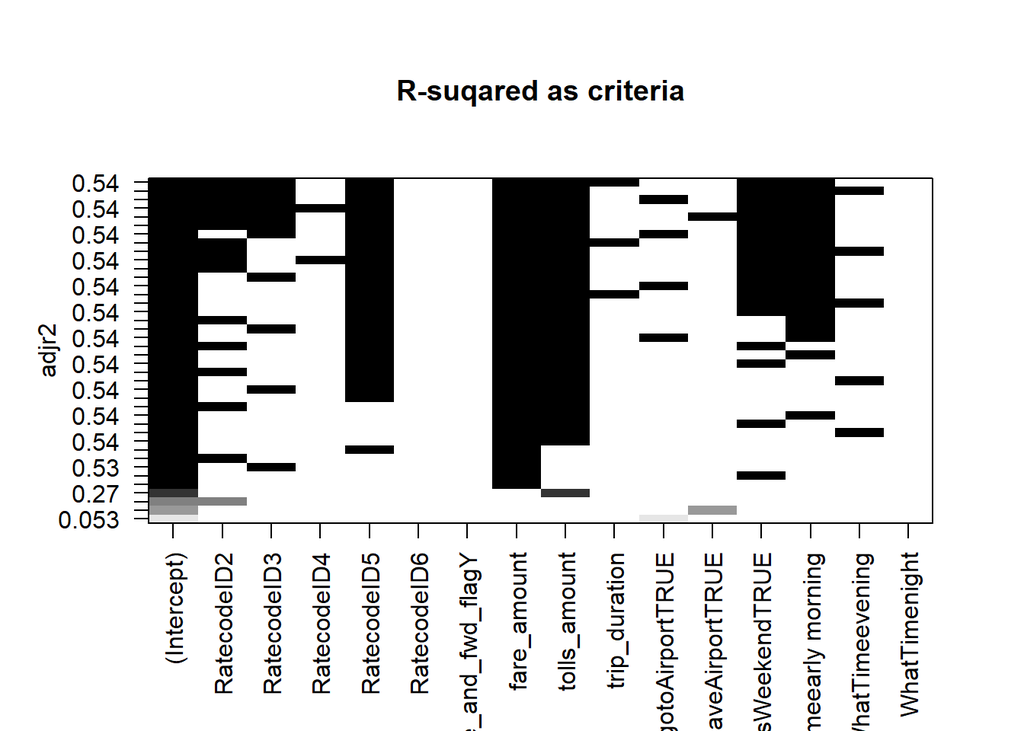

```r
plot(leaps, scale = "adjr2", main = "R-suqared as criteria")
```

```r
summary(leaps)$which[which.max(reg$adjr2),]
```

```
##           (Intercept)           RatecodeID2           RatecodeID3
##                  TRUE                  TRUE                  TRUE
##           RatecodeID4           RatecodeID5           RatecodeID6
##                 FALSE                  TRUE                 FALSE
##   store_and_fwd_flagY           fare_amount          tolls_amount
##                 FALSE                  TRUE                  TRUE
##         trip_duration       gotoAirportTRUE      leaveAirportTRUE
##                  TRUE                 FALSE                 FALSE
##         isWeekendTRUE WhatTimeearly morning       WhatTimeevening
##                  TRUE                  TRUE                 FALSE
##         WhatTimenight
##                 FALSE
```

```r
taxi.lm_3 = lm(tip_amount ~ (RatecodeID==2)+(RatecodeID==3)+(RatecodeID==5)+fare_amount+isWeekend+trip_duration+(WhatTime=="early morning"), data =taxi_lm)
summary(taxi.lm_3)
```

```
##
## Call:
## lm(formula = tip_amount ~ (RatecodeID == 2) + (RatecodeID ==
##     3) + (RatecodeID == 5) + fare_amount + isWeekend + trip_duration +
##     (WhatTime == "early morning"), data = taxi_lm)
##
## Residuals:
##     Min      1Q  Median      3Q     Max
## -105.06   -0.26    0.07    0.31  889.74
##
## Coefficients:
##                                   Estimate Std. Error t value Pr(>|t|)
## (Intercept)                      4.011e-01  2.692e-03  148.97   <2e-16 ***
## RatecodeID == 2TRUE              6.877e-01  1.182e-02   58.16   <2e-16 ***
## RatecodeID == 3TRUE              1.885e+00  3.772e-02   49.97   <2e-16 ***
## RatecodeID == 5TRUE             -2.466e+00  2.562e-02  -96.24   <2e-16 ***
## fare_amount                      1.785e-01  1.651e-04 1081.44   <2e-16 ***
## isWeekendTRUE                   -1.168e-01  3.097e-03  -37.71   <2e-16 ***
## trip_duration                   -4.157e-04  2.926e-05  -14.21   <2e-16 ***
## WhatTime == "early morning"TRUE -1.104e-01  3.159e-03  -34.94   <2e-16 ***
## ---
## Signif. codes:  0 '***' 0.001 '**' 0.01 '*' 0.05 '.' 0.1 ' ' 1
##
## Residual standard error: 1.834 on 1773370 degrees of freedom
## Multiple R-squared:  0.5324, Adjusted R-squared:  0.5324
## F-statistic: 2.885e+05 on 7 and 1773370 DF,  p-value: < 2.2e-16
```

```r
taxi.pred_3 <- predict(taxi.lm_3, taxi_test, interval = "prediction", level = 0.95)
#MSPE
mean((taxi_test$tip_amount-taxi.pred_3[,1])^2)
```

```
## [1] 4.597216
```

But the MSPE is not good.

I use *stepAIC()* from MASS package to do model selection again.

```r
library(MASS)
taxi.step <- stepAIC(taxi.lm_2, direction = "backward")
```

```
## Start:  AIC=2113925
## tip_amount ~ (passenger_count + trip_distance + RatecodeID +
##     store_and_fwd_flag + fare_amount + tolls_amount + dow + trip_duration +
##     gotoAirport + leaveAirport + isWeekend + WhatTime) - passenger_count -
##     dow - trip_distance
##
##                      Df Sum of Sq     RSS     AIC
## <none>                            5840993 2113925
## - store_and_fwd_flag  1        18 5841011 2113928
## - leaveAirport        1        28 5841021 2113931
## - gotoAirport         1       142 5841135 2113966
## - trip_duration       1       501 5841494 2114075
## - isWeekend           1      3627 5844620 2115023
## - WhatTime            3      5671 5846664 2115639
## - RatecodeID          5     32266 5873259 2123684
## - tolls_amount        1    122245 5963238 2150654
## - fare_amount         1   2404929 8245922 2725415
```

```r
summary(taxi.step)
```

```
##
## Call:
## lm(formula = tip_amount ~ (passenger_count + trip_distance +
##     RatecodeID + store_and_fwd_flag + fare_amount + tolls_amount +
##     dow + trip_duration + gotoAirport + leaveAirport + isWeekend +
##     WhatTime) - passenger_count - dow - trip_distance, data = taxi_lm)
##
## Residuals:
##    Min     1Q Median     3Q    Max
## -96.00  -0.28   0.07   0.38 890.88
##
## Coefficients:
##                         Estimate Std. Error t value Pr(>|t|)
## (Intercept)            4.896e-01  3.609e-03 135.643  < 2e-16 ***
## RatecodeID2            2.382e-01  1.677e-02  14.202  < 2e-16 ***
## RatecodeID3           -7.014e-01  3.967e-02 -17.682  < 2e-16 ***
## RatecodeID4            6.025e-01  7.368e-02   8.176 2.93e-16 ***
## RatecodeID5           -2.391e+00  2.541e-02 -94.113  < 2e-16 ***
## RatecodeID6            5.210e+00  1.820e+00   2.863  0.00420 **
## store_and_fwd_flagY    4.443e-02  1.915e-02   2.320  0.02032 *
## fare_amount            1.631e-01  1.909e-04 854.489  < 2e-16 ***
## tolls_amount           2.525e-01  1.311e-03 192.651  < 2e-16 ***
## trip_duration         -3.571e-04  2.895e-05 -12.334  < 2e-16 ***
## gotoAirportTRUE        1.425e-01  2.172e-02   6.562 5.31e-11 ***
## leaveAirportTRUE      -4.275e-02  1.467e-02  -2.915  0.00356 **
## isWeekendTRUE         -1.021e-01  3.076e-03 -33.183  < 2e-16 ***
## WhatTimeearly morning -8.530e-02  3.902e-03 -21.861  < 2e-16 ***
## WhatTimeevening        6.716e-02  4.271e-03  15.726  < 2e-16 ***
## WhatTimenight          4.025e-02  3.720e-03  10.818  < 2e-16 ***
## ---
## Signif. codes:  0 '***' 0.001 '**' 0.01 '*' 0.05 '.' 0.1 ' ' 1
##
## Residual standard error: 1.815 on 1773362 degrees of freedom
## Multiple R-squared:  0.5423, Adjusted R-squared:  0.5423
## F-statistic: 1.401e+05 on 15 and 1773362 DF,  p-value: < 2.2e-16
```

```r
taxi.pred_step <- predict(taxi.step, taxi_test, interval = "prediction", level = 0.95)
#MSPE
mean((taxi_test$tip_amount-taxi.pred_step[,1])^2)
```

```
## [1] 4.502586
```

```r
vif(taxi.step)
```

```
##                        GVIF Df GVIF^(1/(2*Df))
## RatecodeID         3.989347  5        1.148392
## store_and_fwd_flag 1.001703  1        1.000851
## fare_amount        2.274769  1        1.508234
## tolls_amount       1.849212  1        1.359857
## trip_duration      1.030318  1        1.015046
## gotoAirport        1.744805  1        1.320911
## leaveAirport       2.139406  1        1.462671
## isWeekend          1.023897  1        1.011878
## WhatTime           1.032334  3        1.005318
```

*stepAIC()* and *regsubsets* give us two best models in two criteria.

The MSPE of the model that *stepAIC()* gives is smaller which has the smallest AIC too.

```r
taxi.lm_final = lm(tip_amount ~  fare_amount + tolls_amount +  gotoAirport+isWeekend+RatecodeID + WhatTime+ isWeekend, data =taxi_lm)
summary(taxi.lm_final)
```

```
##
## Call:
## lm(formula = tip_amount ~ fare_amount + tolls_amount + gotoAirport +
##     isWeekend + RatecodeID + WhatTime + isWeekend, data = taxi_lm)
##
## Residuals:
##    Min     1Q Median     3Q    Max
## -95.74  -0.28   0.07   0.38 890.93
##
## Coefficients:
##                         Estimate Std. Error t value Pr(>|t|)
## (Intercept)            0.4894419  0.0035745 136.927  < 2e-16 ***
## fare_amount            0.1626450  0.0001819 894.285  < 2e-16 ***
## tolls_amount           0.2532156  0.0013020 194.486  < 2e-16 ***
## gotoAirportTRUE        0.1722544  0.0193414   8.906  < 2e-16 ***
## isWeekendTRUE         -0.1019177  0.0030755 -33.139  < 2e-16 ***
## RatecodeID2            0.2101863  0.0133128  15.788  < 2e-16 ***
## RatecodeID3           -0.6936706  0.0396570 -17.492  < 2e-16 ***
## RatecodeID4            0.6010580  0.0735563   8.171 3.05e-16 ***
## RatecodeID5           -2.3732724  0.0253566 -93.596  < 2e-16 ***
## RatecodeID6            5.1444508  1.8196233   2.827   0.0047 **
## WhatTimeearly morning -0.0850369  0.0039019 -21.794  < 2e-16 ***
## WhatTimeevening        0.0671586  0.0042710  15.724  < 2e-16 ***
## WhatTimenight          0.0406951  0.0037201  10.939  < 2e-16 ***
## ---
## Signif. codes:  0 '***' 0.001 '**' 0.01 '*' 0.05 '.' 0.1 ' ' 1
##
## Residual standard error: 1.815 on 1773365 degrees of freedom
## Multiple R-squared:  0.5423, Adjusted R-squared:  0.5423
## F-statistic: 1.751e+05 on 12 and 1773365 DF,  p-value: < 2.2e-16
```

```r
vif(taxi.lm_final)
```

```
##                  GVIF Df GVIF^(1/(2*Df))
## fare_amount  2.064885  1        1.436971
## tolls_amount 1.824044  1        1.350572
## gotoAirport  1.383027  1        1.176022
## isWeekend    1.023719  1        1.011790
## RatecodeID   2.425552  5        1.092650
## WhatTime     1.032039  3        1.005270
```

```r
taxi.pred_final <- predict(taxi.lm_final, taxi_test, interval = "prediction", level = 0.95)
#MSPE
mean((taxi_test$tip_amount-taxi.pred_final[,1])^2)
```

```
## [1] 4.502384
```

The MSPE is about 4.5, that means the prediction error of every trip’s tip amount is about 2 in week4 data.

## Interpret model and accuracy

- The p-value of every variable in the model is good enough which means all variables are significant.
- Generally, variables in the model are sensible. And the number of variables is 6, which is easy for people to understand.
- The face validity is OK, but not very good. The prediction is plausiable.
  - The 1 unit fare_amount increase, about 0.16 unit tip amount increase.
  - The 1 unit tolls_amount increase, about 0.25 unit tip amount increase.
  - Passengers with RatecodeID 6 (group ride) prefer pay about 5.14 dollars tip more.
  - And people who go to airport pay 0.17 dollars tip more.
  - People who have trip in weekend has pay about 0.1 dollars tip less.
- The R-squared is 0.5423,which means the model can explain about 54% data in week2 data.

However, after model selection, the accuracy doesn’t improve much. The MSPE is about 4.5, that means the prediction error of every trip’s tip amount is about 2 in week4 data.

It is possible that linear model without interaction variable can’t fit the data well. We can add interaction term into the model and do model selection again.